# Starting with R and RMarkdown

# R Markdown

The file you are reading is called an R Markdown document. Markdown is a simple formatting syntax for authoring HTML, PDF, and MS Word documents. For more details, see http://rmarkdown.rstudio.com.

1. Try compiling this document using the “Knit” button. What files are produced?

Now we will install some packages! Note it may take ~5-10 minutes to run all these steps. **You need to run these steps in the order listed.**

### install a package

2. Copy and paste the following code into the console (the lower left panel/pane): install.packages(“tidyverse”)

This code will install a package from CRAN called “tidyverse”.  
You may be asked a question in the console when you do this. If so, answer by typing Yes into the console.

**Troubleshooting**

- You may get an error that says something about `Rtools`, if so follow these instructions:https://docs.google.com/viewer?url=https://raw.githubusercontent.com/jhudsl/intro_to_r/main/resources/rtools_windows.pdf.
- If R keeps asking you to restart, you only need to do this once and can say no after that.

### Load a package into memory

3. Next copy and paste the following code again into the console (the lower left panel/pane): library(tidyverse)

This code loads the tidyverse package into memory- in other words we can use the functions within the package.  
You may be asked a question in the console when you do this. If so, answer by typing Yes into the console.

### The code

The gray area below is a code chunk that will set up our packages and data (this will not show up in the rendered report when we press knit). You can also run the code within the editor area by pressing the green play button. Don’t worry right now about what the code is doing, we will cover this later.

4. Press the green play button. What happens (check the environment too!)?

**Troubleshooting**

- If you are on one drive, this can cause issues with loading the data from the url. Try using this file outside of one drive if this happens.

```r
knitr::opts_chunk$set(echo = TRUE)
library(tidyverse)

long <- read_csv("https://jhudatascience.org/intro_to_r/data/circulator_long.csv")
## take just average ridership per day
avg <- long %>%
  filter(type == "Average")
# keep non-missing data
avg <- avg %>%
  filter(!is.na(number))
```

When code is in an RMarkdown file chunk, it is saved to a file. When it is in the console, it is not saved.

The console is useful for installing packages like we just did, this is because we only need to do it once, so we don’t usually need to save the code.

## Plotting some data

Here is code that will make a plot of some data.

5. Try the “run all chunks above” button that is to the left of the play button on the following chunk. What happens?
6. Then press the play button on this same chunk. What happens?

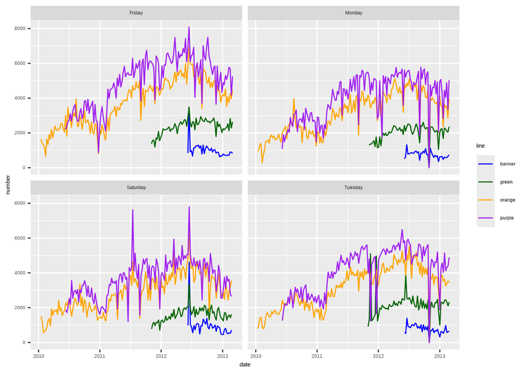

```r
# keep only some days
avg <- avg %>%
  filter(day %in% c("Monday", "Tuesday", "Friday", "Saturday"))

palette <- c(
  banner = "blue",
  green = "darkgreen",
  orange = "orange",
  purple = "purple"
)

ggplot(aes(x = date, y = number, colour = line), data = avg) +
  geom_line() +
  facet_wrap(~day) +
  scale_colour_manual(values = palette)
```

### Adding new chunks

7. Add a new R chunk after `<!-- Your code chunk goes here -->`. You can use the insert chunk button or copy paste an existing code chunk. Include a lowercase x inside the chunk as the code. Make sure you press the knit button after this to see what the new chunk looks like.

```r
x <- c(1, 2, 3)
```

# Practice on Your Own!

### P.1

Go through the code for the plot above and change the colors in `palette` to something other than what they originally were. See https://r-charts.com/colors/ for a large list of colors. For example, you could replace blue with red.

### P.2

Create another R Markdown Document from RStudio dropdowns: File → New File → R Markdown.

### P.3

Add a new header with two hash symbols `##` at the start of a line with some text. Knit the report to see how it looks.